# Importing and Processing CSV Files

Marc Los Huertos

12/6/2016

## Importing CSV Files

First, we will import the CSV file. In most cases, we don’t need to preprocess the csv files.

```r
#Importing Scripts

file = "/home/CAMPUS/mwl04747/github/Climate_Change_Narratives/Olivia/856083.csv"

import = read.csv(file)
```

## Checking the Data

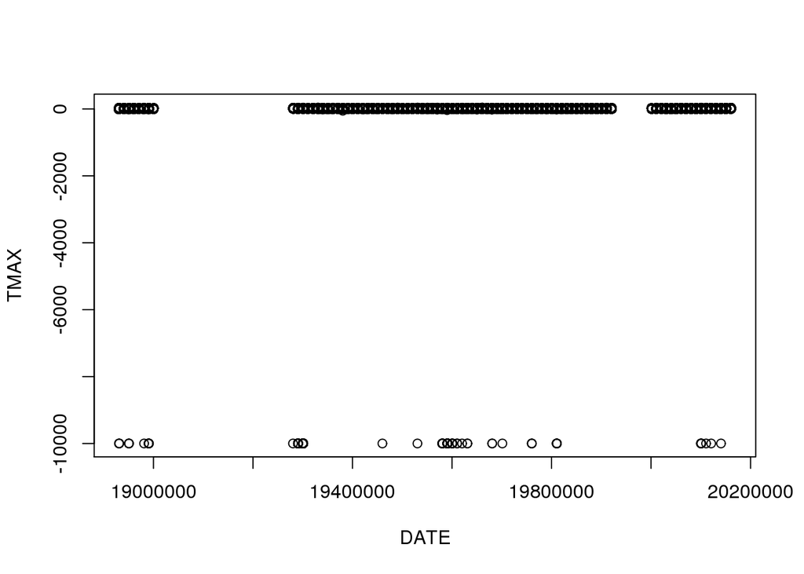

```r
plot(TMAX~DATE, import)
```

What’s going on? What is the deal with the -9999? These are used for missing data. We need to remove them!

```r
import$TMAX[import$TMAX==-9999] = NA
import$TMIN[import$TMIN==-9999] = NA
```

Okay, now we’ll check again, for dates less then Dec. 31, 1913:

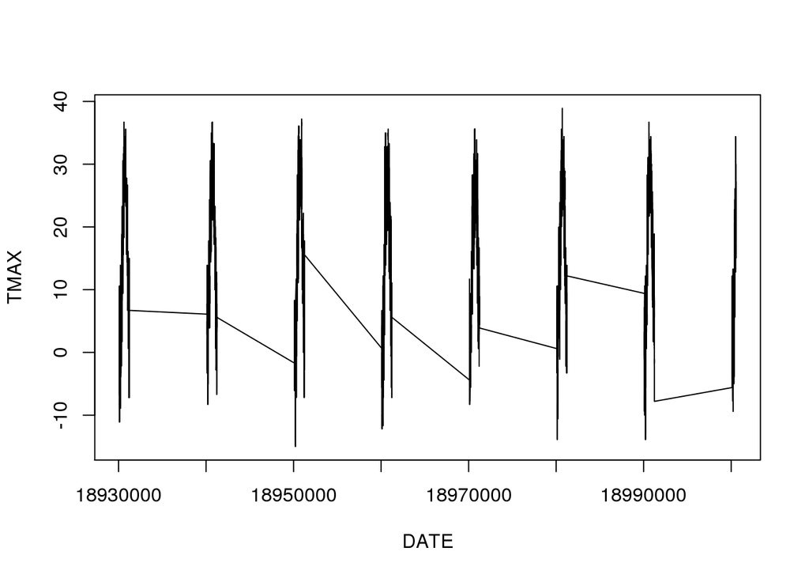

```r
plot(TMAX~DATE, import[import$DATE<19131231,], ty='l')
```

Yikes! What’s wrong? As it turns it the problem is that with how the dates are specified. In particular, the Dec 31 to Jan 1 transition:

19132131 -> 19140101, if you use these as numbers it should be 19131232, 19131232, etc. You see we are missing lots numbers!

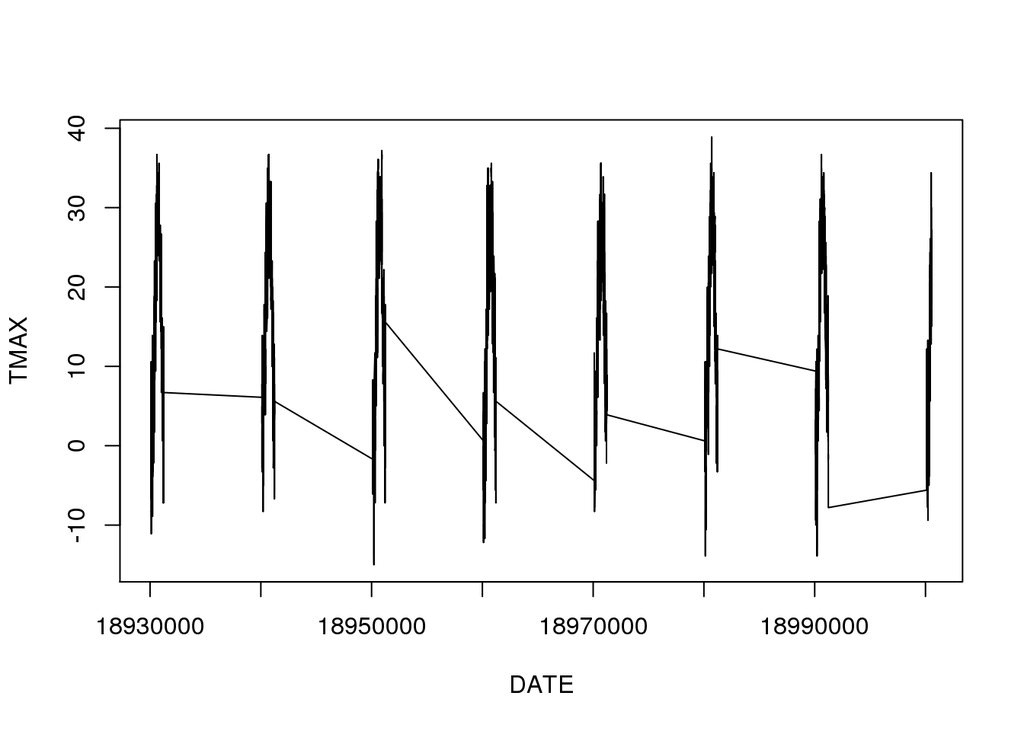

```r
plot(TMAX~DATE, import[import$DATE<19130102,], ty='l')
```

## Fixing the Dates

First, we convert the date a string or character values. Next, we’ll convert the strings to a data format.

```r
strDates <- as.character(import$DATE)
head(strDates)
```

```
## [1] "19481101" "19481102" "19481103" "19481104" "19481105" "19481106"
```

```r
import$NewDate <- as.Date(strDates, "%Y%m%d")
```

## Checking the New Dates

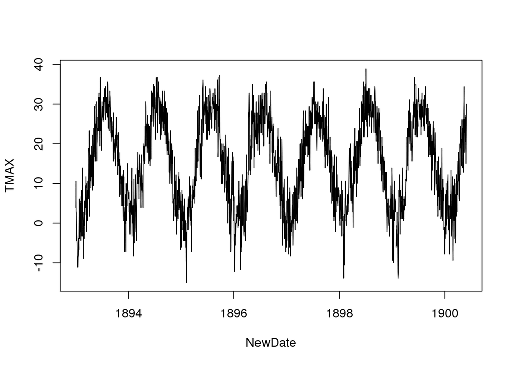

```r
plot(TMAX~NewDate, import[import$DATE<19130102,], ty='l')
```

## Subset Sites

Olivia has two sites in here data, so, we need to subset it.

```r
unique(import$STATION_NAME)
```

```
## [1] POUGHKEEPSIE AIRPORT NY US POUGHKEEPSIE NY US
## Levels: POUGHKEEPSIE AIRPORT NY US POUGHKEEPSIE NY US
```

Let’s choose the POUGHKEEPSIE NY US because the record is longer than the airport.

```r
poughkeepsie <- subset(import, STATION_NAME=="POUGHKEEPSIE NY US", select=c(STATION, STATION_NAME, LONGITUDE, LATITUDE, ELEVATION, DATE, NewDate, TMIN, TMAX))


## A new plot
```

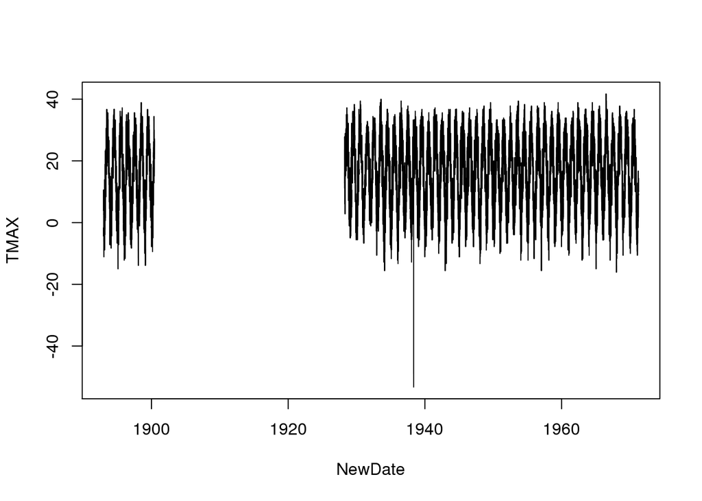

```r
plot(TMAX~NewDate, poughkeepsie, ty='l')
```

## Evaluating the trend

Creating a linear model and then evaluate the rate (slope).

```r
# Linear Model
poughkeepsie.lm <- lm(TMAX~NewDate, data=poughkeepsie)
summary(poughkeepsie.lm)
```

```
##
## Call:
## lm(formula = TMAX ~ NewDate, data = poughkeepsie)
##
## Residuals:
##     Min      1Q  Median      3Q     Max
## -69.571  -9.611   0.960  10.001  24.935
##
## Coefficients:
##              Estimate Std. Error t value Pr(>|t|)
## (Intercept) 1.683e+01  1.355e-01 124.161  < 2e-16 ***
## NewDate     4.796e-05  1.041e-05   4.609 4.07e-06 ***
## ---
## Signif. codes:  0 '***' 0.001 '**' 0.01 '*' 0.05 '.' 0.1 ' ' 1
##
## Residual standard error: 11.3 on 18159 degrees of freedom
##   (206 observations deleted due to missingness)
## Multiple R-squared:  0.001169,   Adjusted R-squared:  0.001113
## F-statistic: 21.24 on 1 and 18159 DF,  p-value: 4.072e-06
```

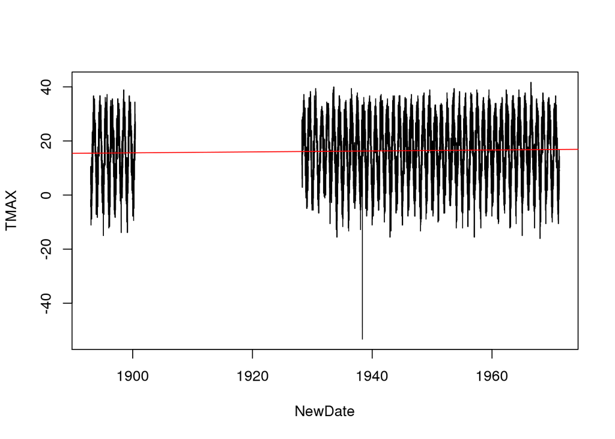

```r
plot(TMAX~NewDate, poughkeepsie, ty='l')
abline(coef(poughkeepsie.lm), col='red')
```

## Creating Month and Year Variables

So, let’s figure out how to see how changes happen for individual months.

```r
# Get months
poughkeepsie$Month = months(poughkeepsie$NewDate)
poughkeepsie$Year = format(poughkeepsie$NewDate, format="%Y")
```

### Creating Monthly Means

```r
MonthlyMean = aggregate(TMAX ~ Month + Year, poughkeepsie, mean)

MonthlyMean$YEAR = as.numeric(MonthlyMean$Year)
head(MonthlyMean)
```

```
##      Month Year      TMAX YEAR
## 1    April 1893 14.630000 1893
## 2   August 1893 29.196774 1893
## 3 December 1893  4.416667 1893
## 4 February 1893  1.721429 1893
## 5  January 1893 -2.522581 1893
## 6     July 1893 29.696774 1893
```

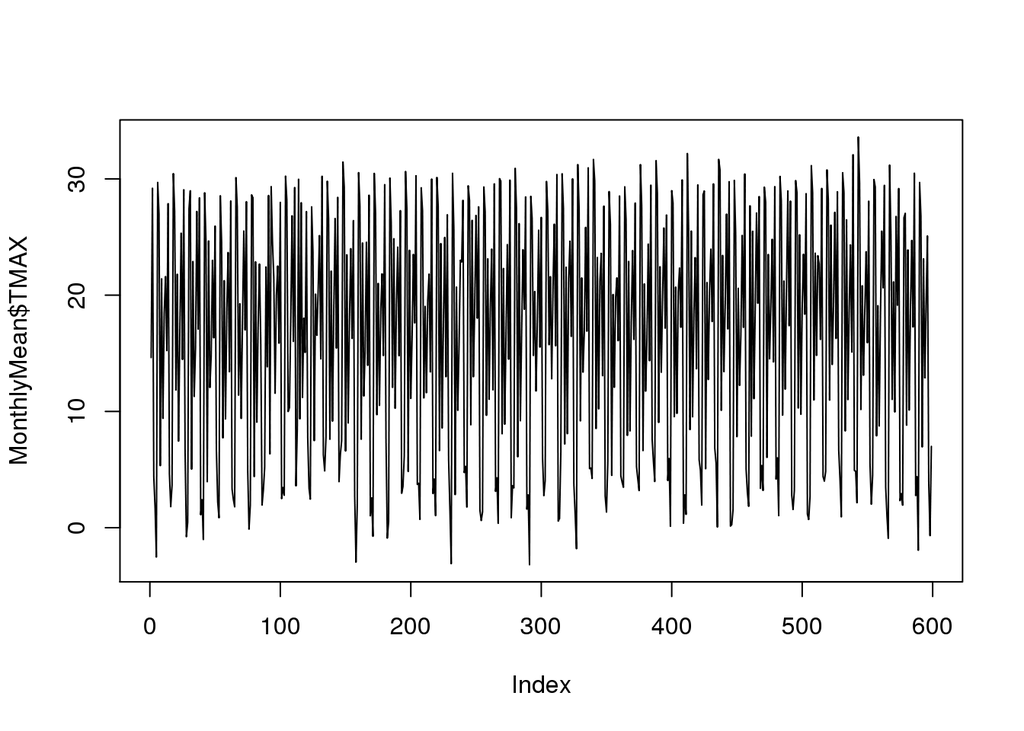

```r
plot(MonthlyMean$TMAX, ty='l')
```

### Selecting for 1 Month – May

Perhaps, we can get a better handle on this stuff if we analyze for just one month at a time – certainly easier to visualize!

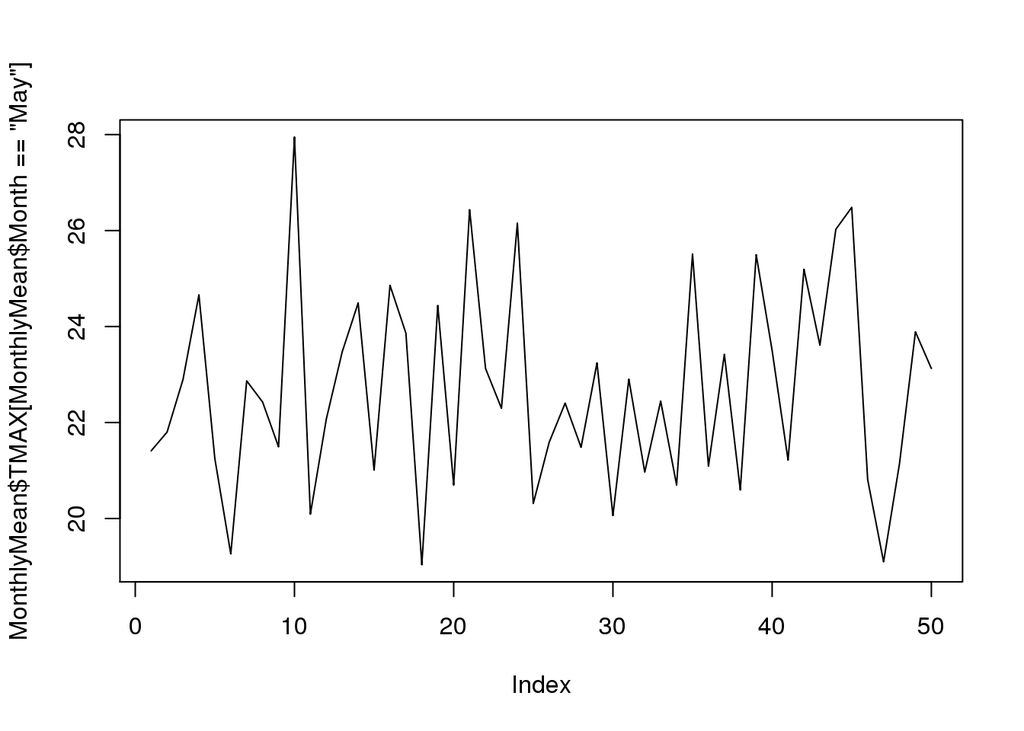

```r
plot(MonthlyMean$TMAX[MonthlyMean$Month=="May"], ty='l')
```

```r
plot(TMAX~YEAR, data=MonthlyMean[MonthlyMean$Month=="May",], ty='l')
May.lm <- lm(TMAX~YEAR, data=MonthlyMean[MonthlyMean$Month=="May",])
summary(May.lm)
```

```
##
## Call:
## lm(formula = TMAX ~ YEAR, data = MonthlyMean[MonthlyMean$Month ==
##     "May", ])
##
## Residuals:
##     Min      1Q  Median      3Q     Max
## -3.8459 -1.7251 -0.1127  1.1418  5.3706
##
## Coefficients:
##              Estimate Std. Error t value Pr(>|t|)
## (Intercept)  3.628966  25.957324   0.140    0.889
## YEAR         0.009819   0.013372   0.734    0.466
##
## Residual standard error: 2.119 on 48 degrees of freedom
## Multiple R-squared:  0.01111,    Adjusted R-squared:  -0.009494
## F-statistic: 0.5392 on 1 and 48 DF,  p-value: 0.4664
```

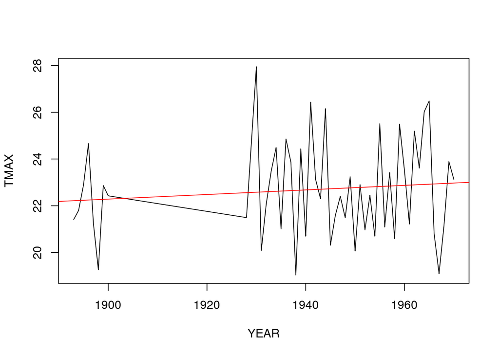

```r
abline(coef(May.lm), col="red")
```

Now, the change is 0.0098189 degress/year or 0.982 degress/100 years (YIKES!) with a probability of 0.4664. Although we can’t reject the null hypothesis, it is worrying!

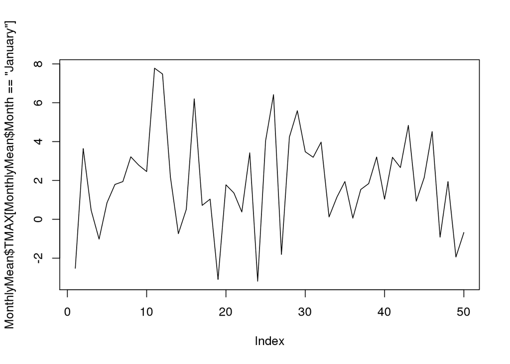

```r
plot(MonthlyMean$TMAX[MonthlyMean$Month=="January"], ty='l')
```

```r
plot(TMAX~YEAR, data=MonthlyMean[MonthlyMean$Month=="January",], ty='l')
January.lm <- lm(TMAX~YEAR, data=MonthlyMean[MonthlyMean$Month=="January",])
summary(January.lm)
```

```
##
## Call:
## lm(formula = TMAX ~ YEAR, data = MonthlyMean[MonthlyMean$Month ==
##     "January", ])
##
## Residuals:
##     Min      1Q  Median      3Q     Max
## -5.1287 -1.3260 -0.1033  1.4961  5.9153
##
## Coefficients:
##              Estimate Std. Error t value Pr(>|t|)
## (Intercept) -9.944983  30.760238  -0.323    0.748
## YEAR         0.006111   0.015840   0.386    0.701
##
## Residual standard error: 2.546 on 48 degrees of freedom
## Multiple R-squared:  0.003092,   Adjusted R-squared:  -0.01768
## F-statistic: 0.1489 on 1 and 48 DF,  p-value: 0.7013
```

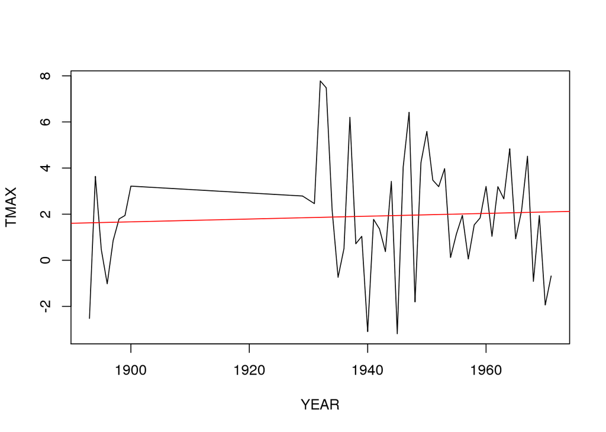

```r
abline(coef(January.lm), col="red")
```

Now, the change is 0.0061114 degress/year or 0.611 degress/100 years with a probability of 0.7013.

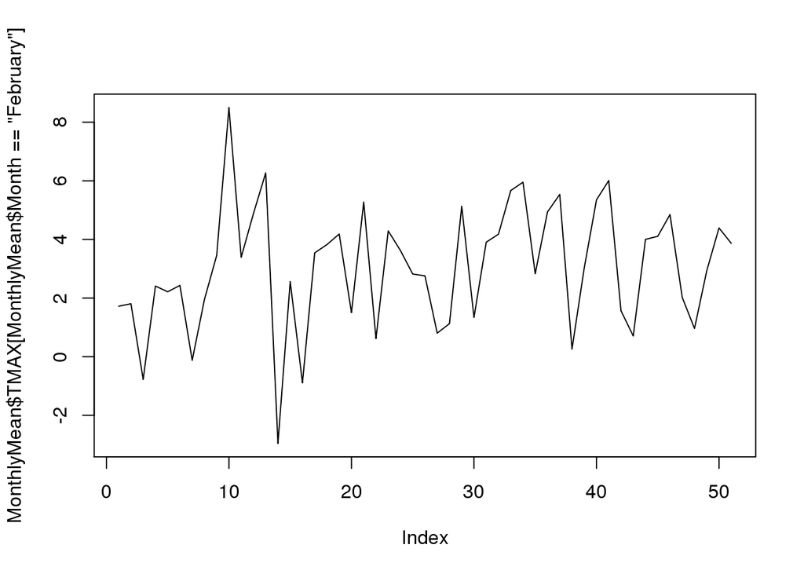

```r
plot(MonthlyMean$TMAX[MonthlyMean$Month=="February"], ty='l')
```

```r
plot(TMAX~YEAR, data=MonthlyMean[MonthlyMean$Month=="February",], ty='l')
February.lm <- lm(TMAX~YEAR, data=MonthlyMean[MonthlyMean$Month=="February",])
summary(February.lm)
```

```
##
## Call:
## lm(formula = TMAX ~ YEAR, data = MonthlyMean[MonthlyMean$Month ==
##     "February", ])
##
## Residuals:
##     Min      1Q  Median      3Q     Max
## -5.7936 -1.5877  0.3748  1.1942  5.7732
##
## Coefficients:
##              Estimate Std. Error t value Pr(>|t|)
## (Intercept) -48.46574   25.01960  -1.937   0.0585 .
## YEAR          0.02652    0.01289   2.059   0.0449 *
## ---
## Signif. codes:  0 '***' 0.001 '**' 0.01 '*' 0.05 '.' 0.1 ' ' 1
##
## Residual standard error: 2.076 on 49 degrees of freedom
## Multiple R-squared:  0.0796, Adjusted R-squared:  0.06081
## F-statistic: 4.238 on 1 and 49 DF,  p-value: 0.04488
```

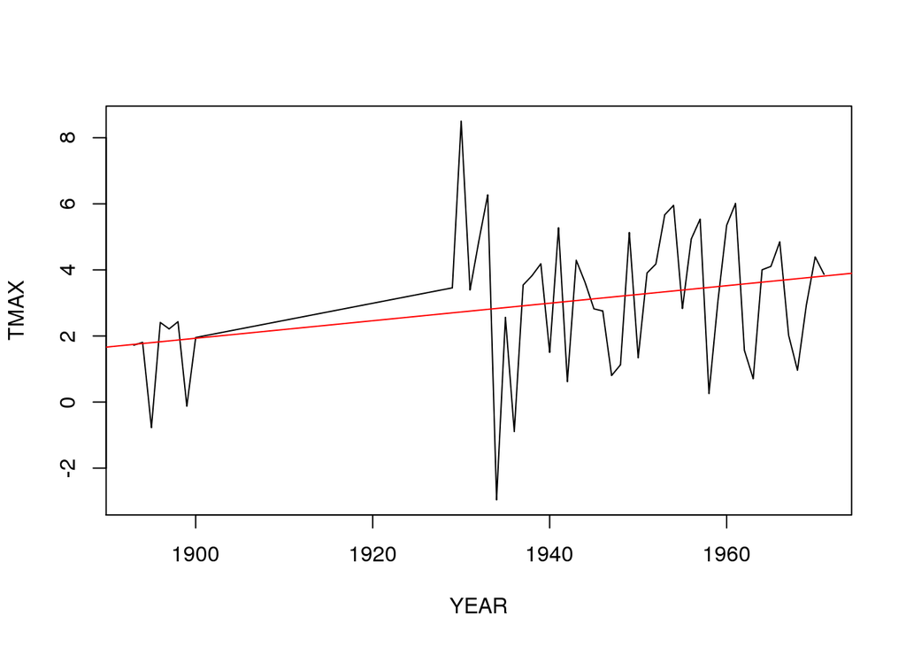

```r
abline(coef(February.lm), col="red")
```

Now, the change is 0.0265246 degress/year or 2.652 degress/100 years with a probability of 0.0449.

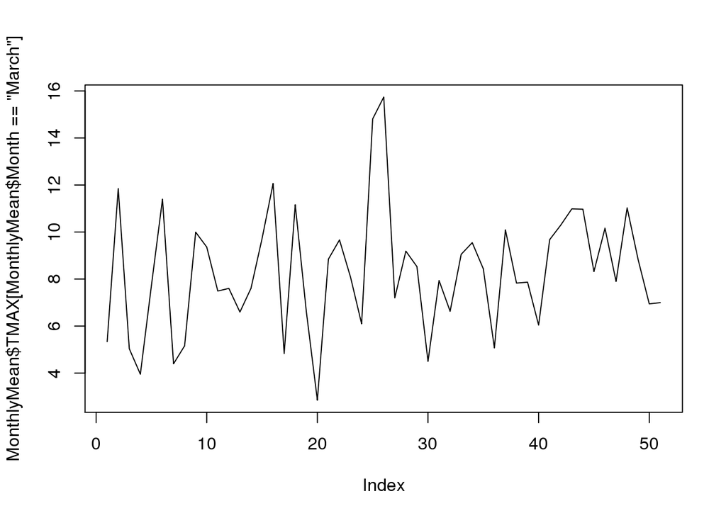

```r
plot(MonthlyMean$TMAX[MonthlyMean$Month=="March"], ty='l')
```

```r
plot(TMAX~YEAR, data=MonthlyMean[MonthlyMean$Month=="March",], ty='l')
March.lm <- lm(TMAX~YEAR, data=MonthlyMean[MonthlyMean$Month=="March",])
summary(March.lm)
```

```
##
## Call:
## lm(formula = TMAX ~ YEAR, data = MonthlyMean[MonthlyMean$Month ==
##     "March", ])
##
## Residuals:
##     Min      1Q  Median      3Q     Max
## -5.4234 -1.8292 -0.2731  1.3622  7.3096
##
## Coefficients:
##              Estimate Std. Error t value Pr(>|t|)
## (Intercept) -42.58376   31.07800  -1.370    0.177
## YEAR          0.02621    0.01601   1.638    0.108
##
## Residual standard error: 2.579 on 49 degrees of freedom
## Multiple R-squared:  0.0519, Adjusted R-squared:  0.03256
## F-statistic: 2.683 on 1 and 49 DF,  p-value: 0.1079
```

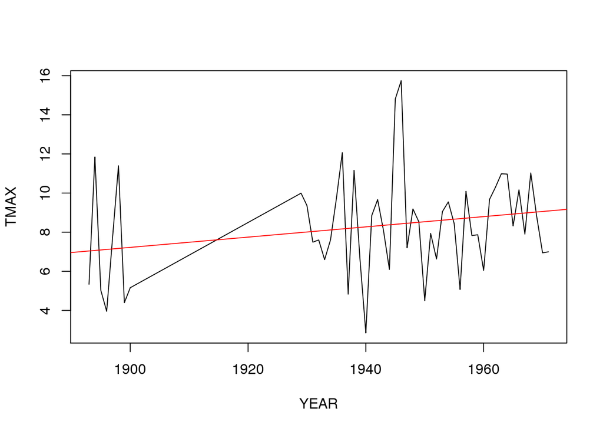

```r
abline(coef(March.lm), col="red")
```

Now, the change is 0.0262142 degress/year or 2.621 degress/100 years with a probability of 0.1079.

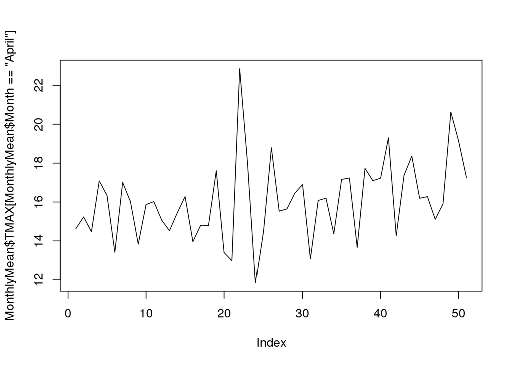

```r
plot(MonthlyMean$TMAX[MonthlyMean$Month=="April"], ty='l')
```

```r
plot(TMAX~YEAR, data=MonthlyMean[MonthlyMean$Month=="April",], ty='l')
April.lm <- lm(TMAX~YEAR, data=MonthlyMean[MonthlyMean$Month=="April",])
summary(April.lm)
```

```
##
## Call:
## lm(formula = TMAX ~ YEAR, data = MonthlyMean[MonthlyMean$Month ==
##     "April", ])
##
## Residuals:
##     Min      1Q  Median      3Q     Max
## -4.2601 -1.2442 -0.1452  0.9025  6.7899
##
## Coefficients:
##              Estimate Std. Error t value Pr(>|t|)
## (Intercept) -32.48310   24.14796  -1.345   0.1848
## YEAR          0.02501    0.01244   2.010   0.0499 *
## ---
## Signif. codes:  0 '***' 0.001 '**' 0.01 '*' 0.05 '.' 0.1 ' ' 1
##
## Residual standard error: 1.977 on 49 degrees of freedom
## Multiple R-squared:  0.07619,    Adjusted R-squared:  0.05734
## F-statistic: 4.041 on 1 and 49 DF,  p-value: 0.04992
```

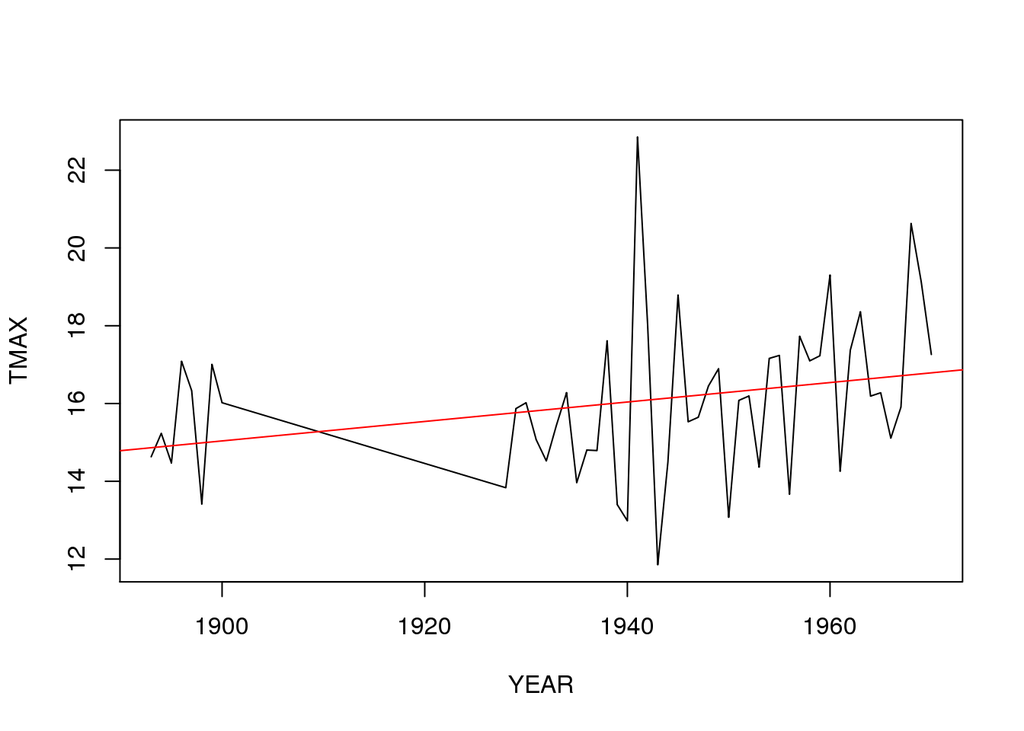

```r
abline(coef(April.lm), col="red")
```

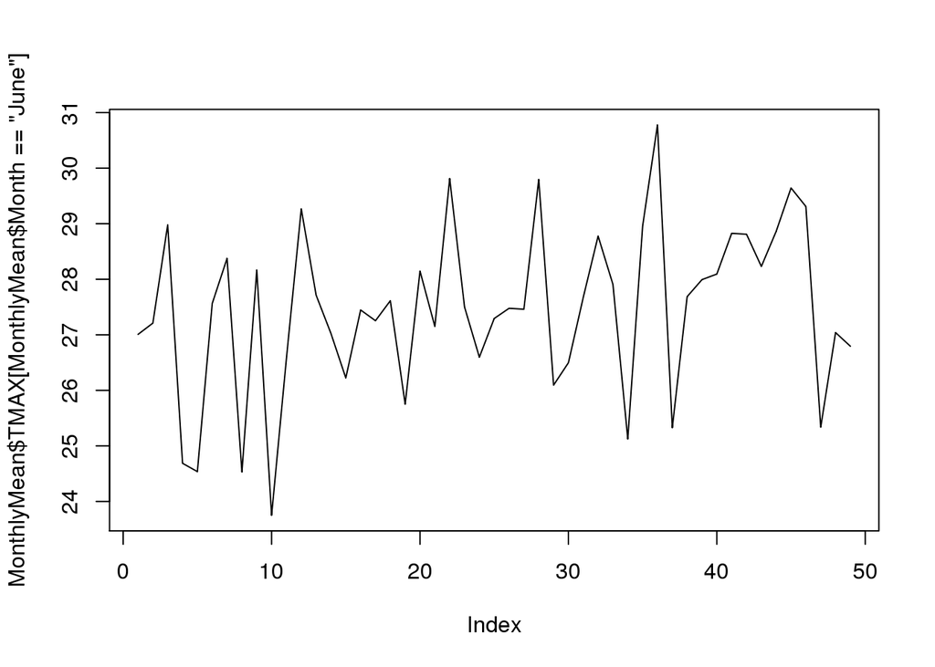

```r
plot(MonthlyMean$TMAX[MonthlyMean$Month=="June"], ty='l')
```

```r
plot(TMAX~YEAR, data=MonthlyMean[MonthlyMean$Month=="June",], ty='l')
June.lm <- lm(TMAX~YEAR, data=MonthlyMean[MonthlyMean$Month=="June",])
summary(January.lm)
```

[output not shown]

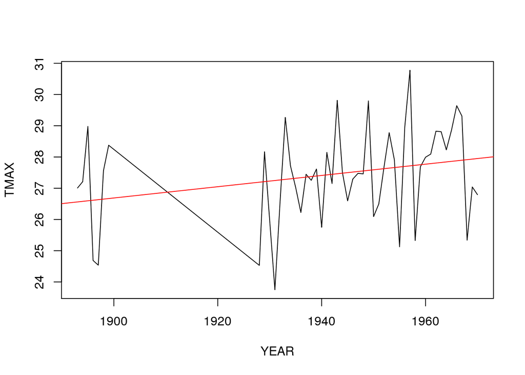

```r
abline(coef(June.lm), col="red")
```

Now, the change is 0.0180432 degress/year or 1.804 degress/100 years with a probability of 0.0701.

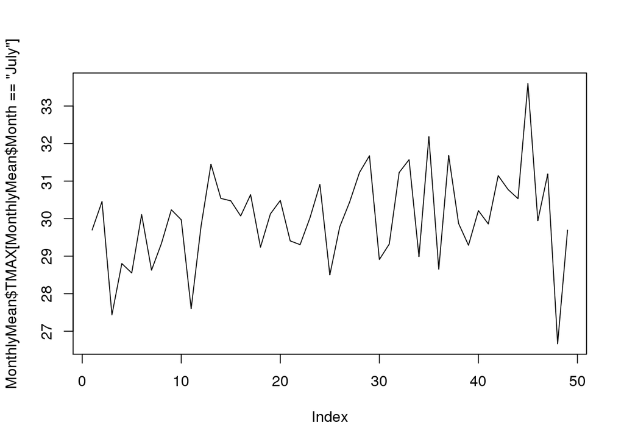

```r
plot(MonthlyMean$TMAX[MonthlyMean$Month=="July"], ty='l')
```

```r
plot(TMAX~YEAR, data=MonthlyMean[MonthlyMean$Month=="July",], ty='l')
July.lm <- lm(TMAX~YEAR, data=MonthlyMean[MonthlyMean$Month=="July",])
summary(July.lm)
```

```
##
## Call:
## lm(formula = TMAX ~ YEAR, data = MonthlyMean[MonthlyMean$Month ==
##     "July", ])
##
## Residuals:
##     Min      1Q  Median      3Q     Max
## -3.8341 -0.6668  0.1047  0.7091  3.1579
##
## Coefficients:
##              Estimate Std. Error t value Pr(>|t|)
## (Intercept) -4.511347  15.319454  -0.294    0.770
## YEAR         0.017781   0.007891   2.253    0.029 *
## ---
## Signif. codes:  0 '***' 0.001 '**' 0.01 '*' 0.05 '.' 0.1 ' ' 1
##
## Residual standard error: 1.203 on 47 degrees of freedom
## Multiple R-squared:  0.09749,    Adjusted R-squared:  0.07829
## F-statistic: 5.077 on 1 and 47 DF,  p-value: 0.02895
```

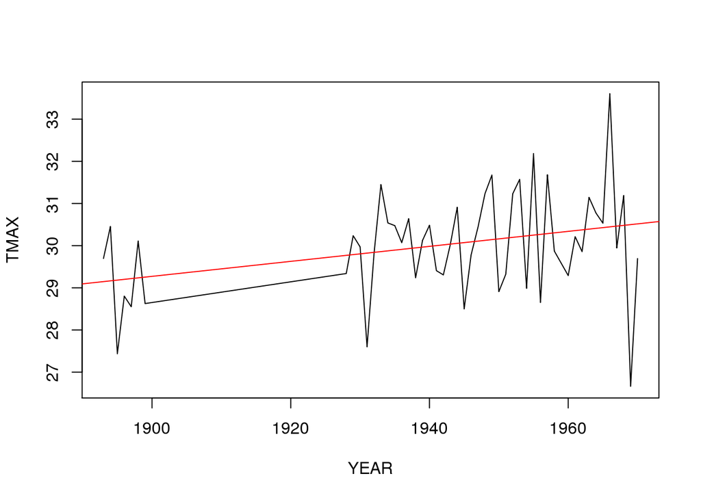

```r
abline(coef(July.lm), col="red")
```

Now, the change is 0.0177806 degress/year or 1.778 degress/100 years with a probability of 0.029.

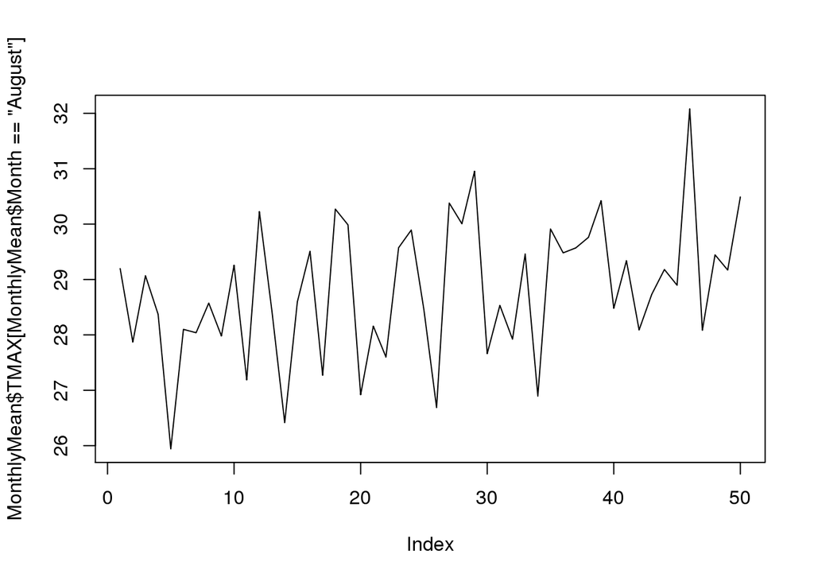

```r
plot(MonthlyMean$TMAX[MonthlyMean$Month=="August"], ty='l')
```

```r
plot(TMAX~YEAR, data=MonthlyMean[MonthlyMean$Month=="August",], ty='l')
August.lm <- lm(TMAX~YEAR, data=MonthlyMean[MonthlyMean$Month=="August",])
summary(August.lm)
```

```
##
## Call:
## lm(formula = TMAX ~ YEAR, data = MonthlyMean[MonthlyMean$Month ==
##     "August", ])
##
## Residuals:
##      Min       1Q   Median       3Q      Max
## -2.24628 -0.67688  0.04388  0.83274  2.79410
##
## Coefficients:
##             Estimate Std. Error t value Pr(>|t|)
## (Intercept) -9.05892   15.00930  -0.604    0.549
## YEAR         0.01950    0.00773   2.523    0.015 *
## ---
## Signif. codes:  0 '***' 0.001 '**' 0.01 '*' 0.05 '.' 0.1 ' ' 1
##
## Residual standard error: 1.186 on 48 degrees of freedom
## Multiple R-squared:  0.1171, Adjusted R-squared:  0.09871
## F-statistic: 6.367 on 1 and 48 DF,  p-value: 0.015
```

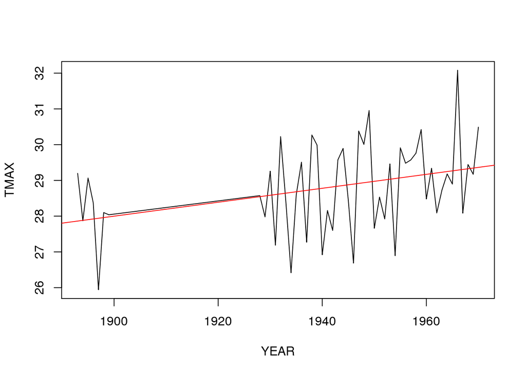

```r
abline(coef(August.lm), col="red")
```

Now, the change is 0.0195043 degress/year or 1.95 degress/100 years with a probability of 0.015.

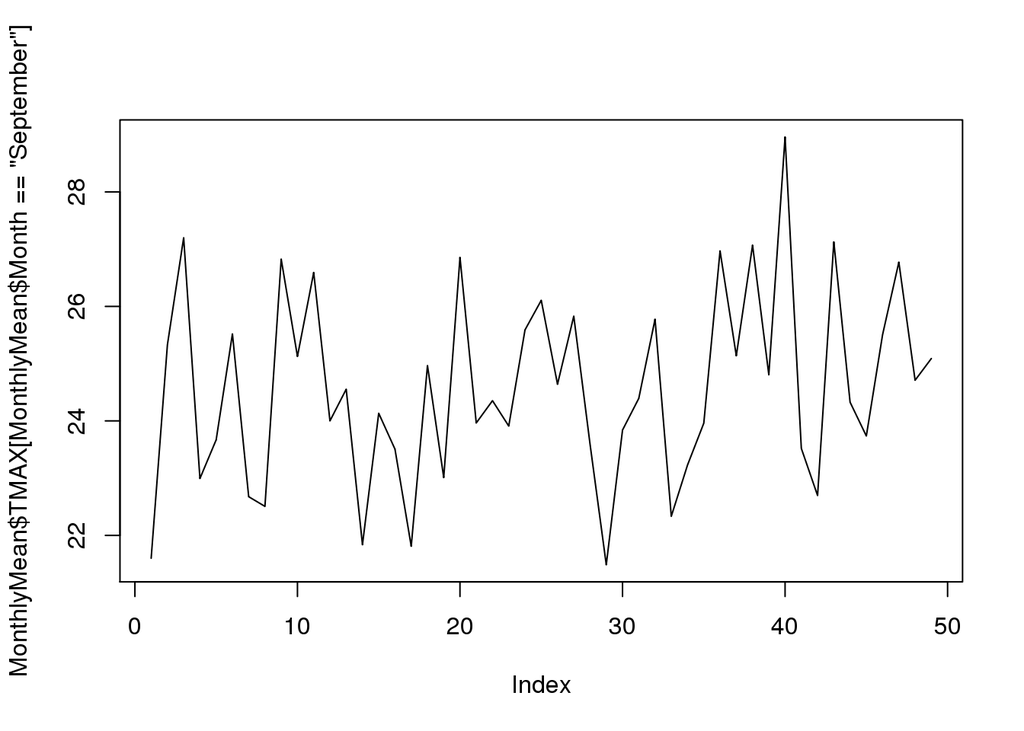

```r
plot(MonthlyMean$TMAX[MonthlyMean$Month=="September"], ty='l')
```

```r
plot(TMAX~YEAR, data=MonthlyMean[MonthlyMean$Month=="September",], ty='l')
September.lm <- lm(TMAX~YEAR, data=MonthlyMean[MonthlyMean$Month=="September",])
summary(September.lm)
```

```
##
## Call:
## lm(formula = TMAX ~ YEAR, data = MonthlyMean[MonthlyMean$Month ==
##     "September", ])
##
## Residuals:
##     Min      1Q  Median      3Q     Max
## -3.2051 -1.0808 -0.2537  1.1669  4.1108
##
## Coefficients:
##             Estimate Std. Error t value Pr(>|t|)
## (Intercept) -3.21443   21.31950  -0.151    0.881
## YEAR         0.01431    0.01098   1.304    0.199
##
## Residual standard error: 1.68 on 47 degrees of freedom
## Multiple R-squared:  0.03489,    Adjusted R-squared:  0.01436
## F-statistic: 1.699 on 1 and 47 DF,  p-value: 0.1987
```

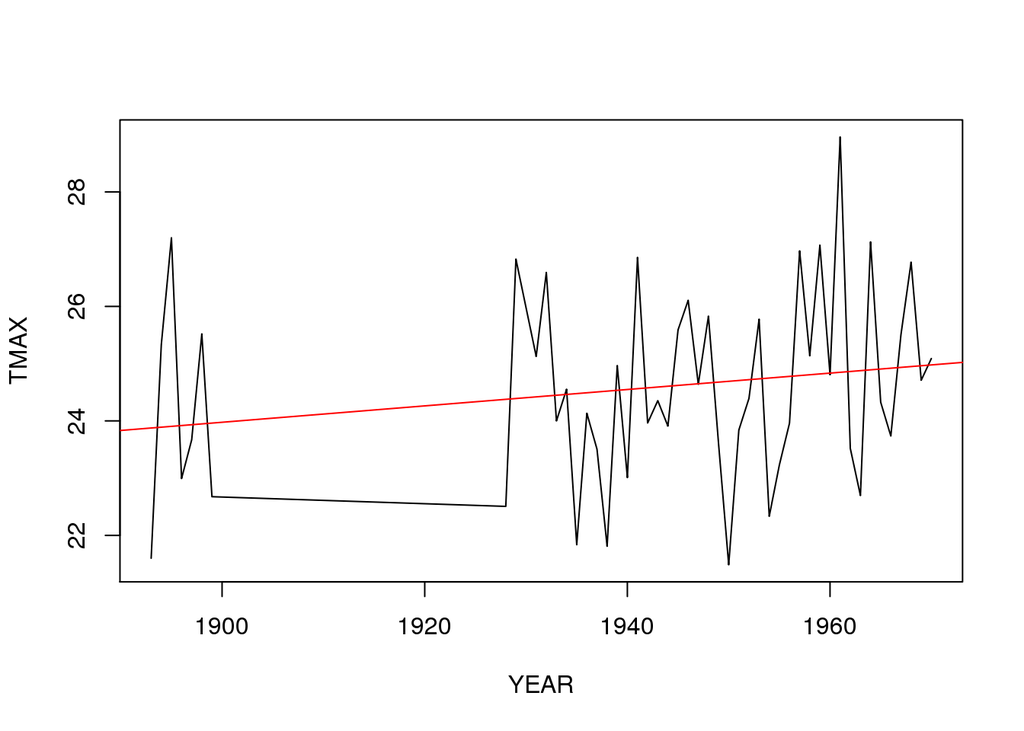

```r
abline(coef(September.lm), col="red")
```

Now, the change is 0.0143109 degress/year or 1.431 degress/100 years with a probability of 0.1987.

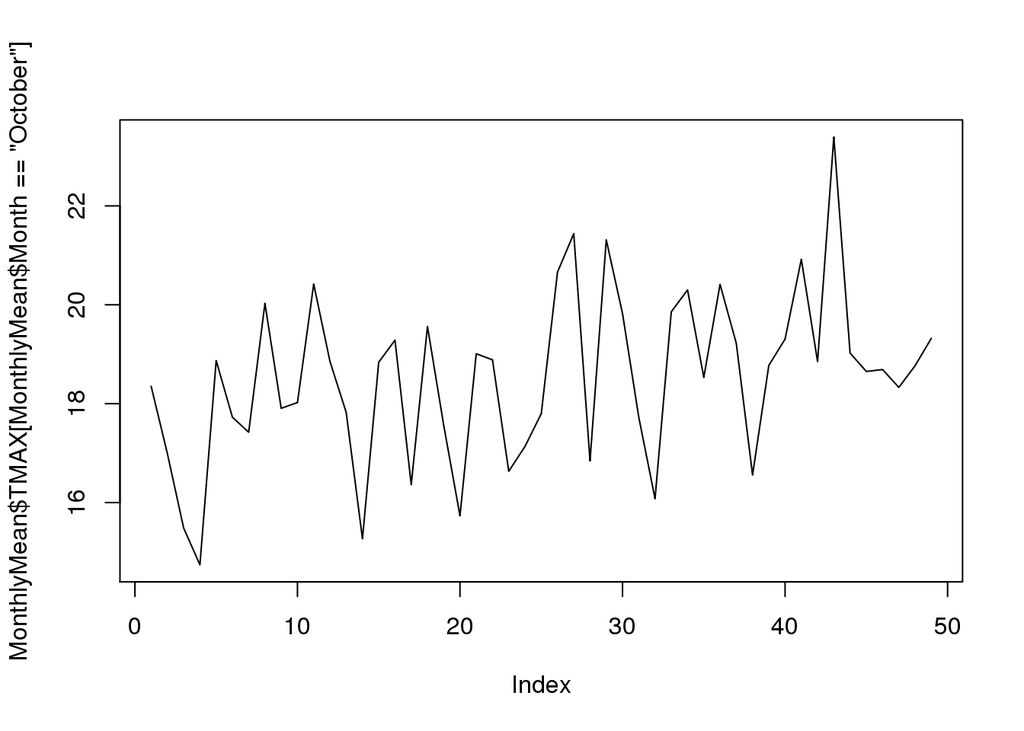

```r
plot(MonthlyMean$TMAX[MonthlyMean$Month=="October"], ty='l')
```

```r
plot(TMAX~YEAR, data=MonthlyMean[MonthlyMean$Month=="October",], ty='l')
October.lm <- lm(TMAX~YEAR, data=MonthlyMean[MonthlyMean$Month=="October",])
summary(October.lm)
```

```
##
## Call:
## lm(formula = TMAX ~ YEAR, data = MonthlyMean[MonthlyMean$Month ==
##     "October", ])
##
## Residuals:
##     Min      1Q  Median      3Q     Max
## -3.0260 -0.8934 -0.1299  1.0138  4.1664
##
## Coefficients:
##              Estimate Std. Error t value Pr(>|t|)
## (Intercept) -43.95499   20.48272  -2.146  0.03707 *
## YEAR          0.03219    0.01055   3.050  0.00375 **
## ---
## Signif. codes:  0 '***' 0.001 '**' 0.01 '*' 0.05 '.' 0.1 ' ' 1
##
## Residual standard error: 1.595 on 47 degrees of freedom
## Multiple R-squared:  0.1653, Adjusted R-squared:  0.1475
## F-statistic: 9.305 on 1 and 47 DF,  p-value: 0.00375
```

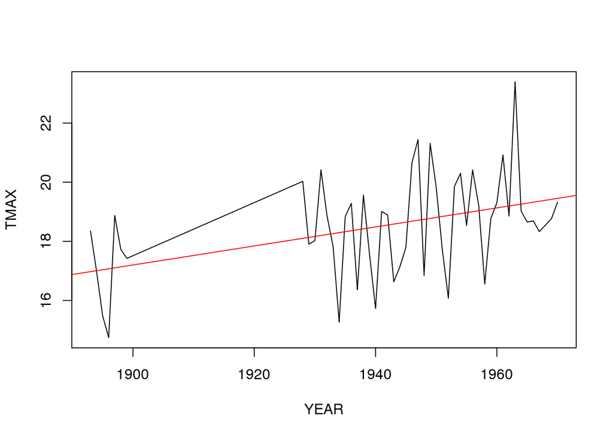

```r
abline(coef(October.lm), col="red")
```

Now, the change is 0.0321865 degress/year or 3.219 degress/100 years with a probability of 0.0038.

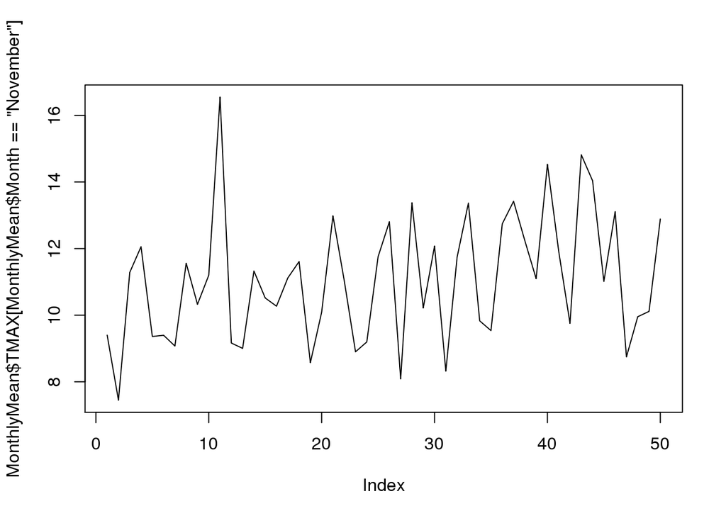

```r
plot(MonthlyMean$TMAX[MonthlyMean$Month=="November"], ty='l')
```

```r
plot(TMAX~YEAR, data=MonthlyMean[MonthlyMean$Month=="November",], ty='l')
November.lm <- lm(TMAX~YEAR, data=MonthlyMean[MonthlyMean$Month=="November",])
summary(November.lm)
```

```
##
## Call:
## lm(formula = TMAX ~ YEAR, data = MonthlyMean[MonthlyMean$Month ==
##     "November", ])
##
## Residuals:
##     Min      1Q  Median      3Q     Max
## -3.1245 -1.6139 -0.1612  1.2164  5.7890
##
## Coefficients:
##              Estimate Std. Error t value Pr(>|t|)
## (Intercept) -43.56313   23.50500  -1.853   0.0700 .
## YEAR          0.02813    0.01211   2.324   0.0244 *
## ---
## Signif. codes:  0 '***' 0.001 '**' 0.01 '*' 0.05 '.' 0.1 ' ' 1
##
## Residual standard error: 1.858 on 48 degrees of freedom
## Multiple R-squared:  0.1011, Adjusted R-squared:  0.08241
## F-statistic: 5.401 on 1 and 48 DF,  p-value: 0.02441
```

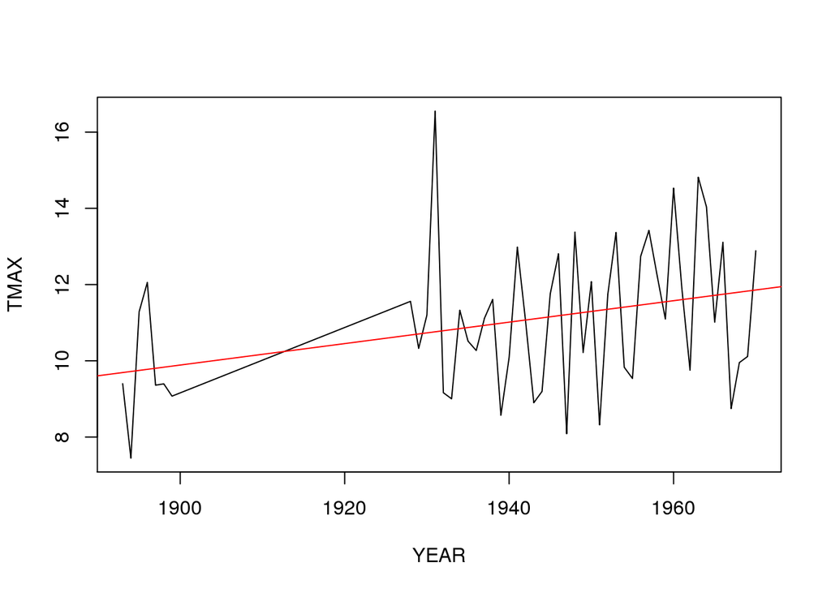

```r
abline(coef(November.lm), col="red")
```

Now, the change is 0.0281327 degress/year or 2.813 degress/100 years with a probability of 0.0244.

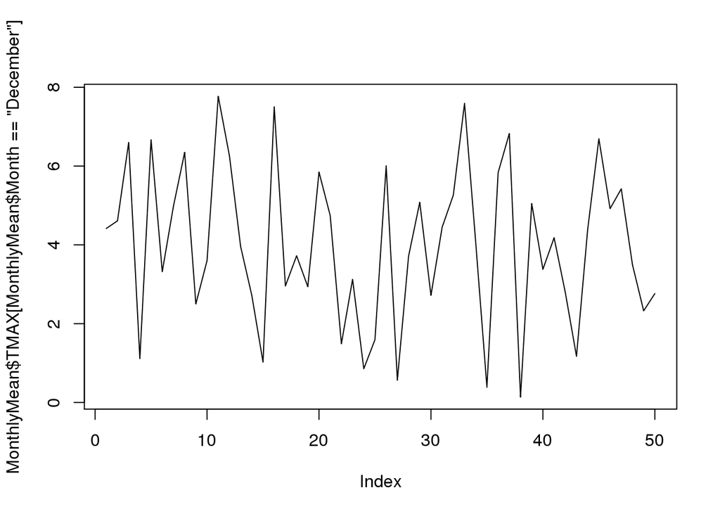

```r
plot(MonthlyMean$TMAX[MonthlyMean$Month=="December"], ty='l')
```

```r
plot(TMAX~YEAR, data=MonthlyMean[MonthlyMean$Month=="December",], ty='l')
December.lm <- lm(TMAX~YEAR, data=MonthlyMean[MonthlyMean$Month=="December",])
summary(December.lm)
```

```
##
## Call:
## lm(formula = TMAX ~ YEAR, data = MonthlyMean[MonthlyMean$Month ==
##     "December", ])
##
## Residuals:
##     Min      1Q  Median      3Q     Max
## -3.6681 -1.1900 -0.1483  1.6416  3.7309
##
## Coefficients:
##             Estimate Std. Error t value Pr(>|t|)
## (Intercept) 26.95757   25.72931   1.048    0.300
## YEAR        -0.01183    0.01325  -0.892    0.377
##
## Residual standard error: 2.034 on 48 degrees of freedom
## Multiple R-squared:  0.01632,    Adjusted R-squared:  -0.004172
## F-statistic: 0.7964 on 1 and 48 DF,  p-value: 0.3766
```

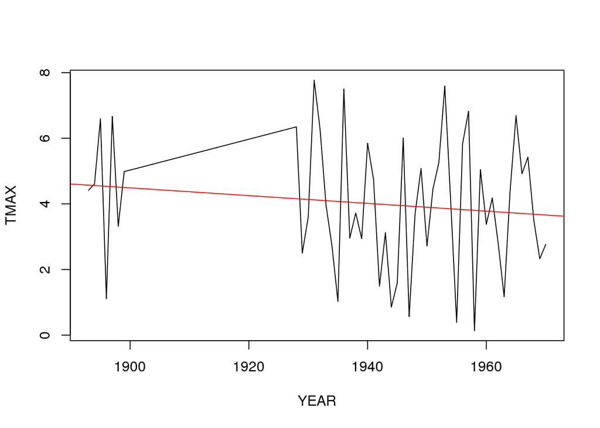

```r
abline(coef(December.lm), col="red")
```

Now, the change is -0.0118253 degress/year or -1.183 degress/100 years with a probability of 0.3766.